# Homework 2

Martin Stelmach

## Examining Jia You’s Online graphic

I believe the graphic is trying to answer the question of “What are the infected population of the given disease and how does that population change after having introduced and implemented a vaccine for the given disease?”. I believe the focus of this graph is to demonstrate that the infected population shrinks immensely after a vaccine is created. I believe the author also wanted to show a ressurgence of the diseases as of the recent trend of antivaxxers. The graphic Jia You’s used is a good graphic for the question posed because it is easy to determine when each disease started and when its respective population dynamics changed by examining the size of the shape. It is also very easy to see key dates due to colour differentiation of certain dates. One prominent issue with the graph is the difficulty of viewing the smaller infected populations on the graph. For example, Mumps begins to make a resurgence in later years however, on the graph it looks like the disease is completely erradicated before it shows up again on the graph.

## First Graphic

The first graphic I made was made with the idea that the goal of the graphic is to correspond to the question. This means we are looking for something that easily demonstrates the disipation of cases after a vaccine has been introduced. The graphic shows the rise of the disease during its year of discovery and then the number of cases plotted against a single X axis of years. I chose to allow a free Y axis per disease because, although the size of each disease is not proportionate to one another, the question we are asking is with resepect to disease growth after vaccine implementation. I also chose to divide my y axis by 1000 for easier ledgibility. I ordered the diseases by max value of cases in the disease so they are asthetically pleasing as according to Cleveland.

Please note in the Rmarkdown file the diseases seem to be squished together and the y axis seems crowded however when we zoom the image in R there seems to be alot more space for everything to render.

```r
library(tidyverse)
library(ggthemes)
df <- readr::read_csv("https://bbolker.github.io/stat744/data/vaccine_data_online.csv")
```

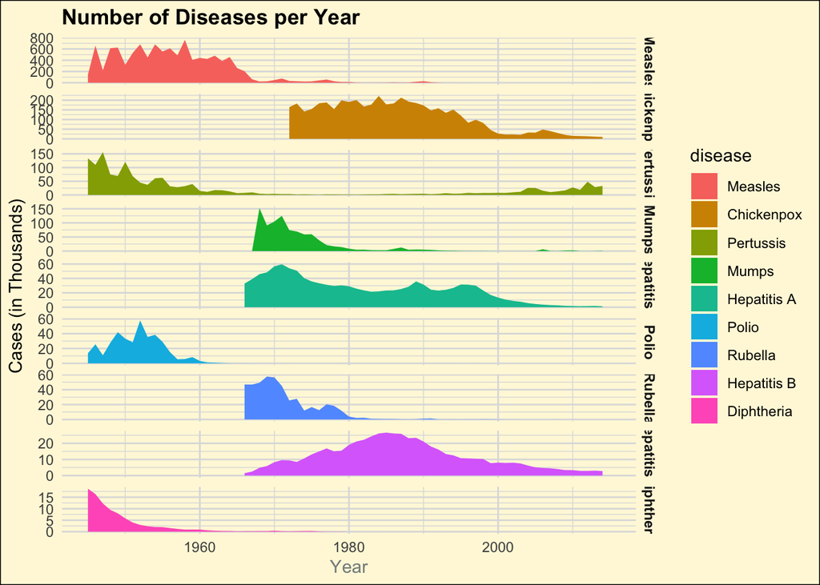

```r
df2 <- (df %>% mutate(cases2=cases/1000,
             #I want the order of biggest max value
             disease = reorder(disease,cases,FUN=function(x) -x[1]))
          )
#this is my order code (possibly just have ordered it twice)
order <- df %>%
  arrange(desc(cases)) %>%
  pull(disease) %>%
  unique()
#apply the order I just made
df2$disease <- factor(df2$disease, levels = order)

#The graph
g2 <- ggplot(df2, aes(x = year, y = cases2, colours=disease, fill = disease)) +
      geom_area() +
      theme_minimal()+
  theme(plot.background = element_rect(fill = "cornsilk"),
        plot.title = element_text(face = "bold"),
        strip.text = element_text(face = "bold"),
        axis.title.x = element_text(colour = "azure4"),
        panel.grid.major = element_line(colour = "gray87"),
        panel.grid.minor = element_line(colour = "gray87")) +
  labs(title = "Number of Diseases per Year",
       x = "Year",
       y = "Cases (in Thousands)") +
      facet_grid(disease ~.,scales ="free_y")
```

## Second Plot

I liked that the 1st one was all on one single X axis however I feel like it would be more legible to have them all on their own respective graphs and view each disease in the 3x3 set of graphs as seen below. I stayed with the same colour theme as the previous graph so it would be easier to compare the two. The seperation of the graphs into a grid is an easier way to differentate the diseases. I chose to leave the free Y axis because without it the smaller diseases were unviewable. I envisioned to have each row a different Y axis rather than each plot have its own scale however I was unable to figure that out. Similarly to the previous graphic this one does not represent each disease to scale with one another but is rather meant to show the significance of the addition of a vaccine.

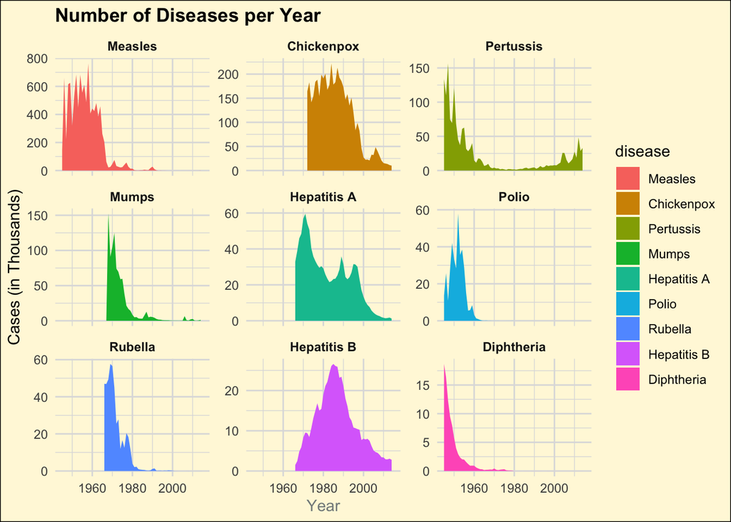

```r
g4 <- ggplot(df2, aes(x = year, y = cases2, colours=disease, fill = disease)) +
  geom_area() +
  facet_wrap(~disease, ncol  = 3, scales = "free_y")+
  theme_minimal()+
  theme(plot.background = element_rect(fill = "cornsilk"),
        plot.title = element_text(face = "bold"),
        strip.text = element_text(face = "bold"),
        axis.title.x = element_text(colour = "azure4"),
        panel.grid.major = element_line(colour = "gray87"),
        panel.grid.minor = element_line(colour = "gray87")) +
  labs(title = "Number of Diseases per Year",
       x = "Year",
       y = "Cases (in Thousands)" )
```